# Exam 1

## Exam 1

#### Question

1. Lucía desea saber cuánto mezcla se necesita para llenar el cañería cilíndrica interno, pero solamente cuenta con las medidas de las dimensiones que muestra la figura.

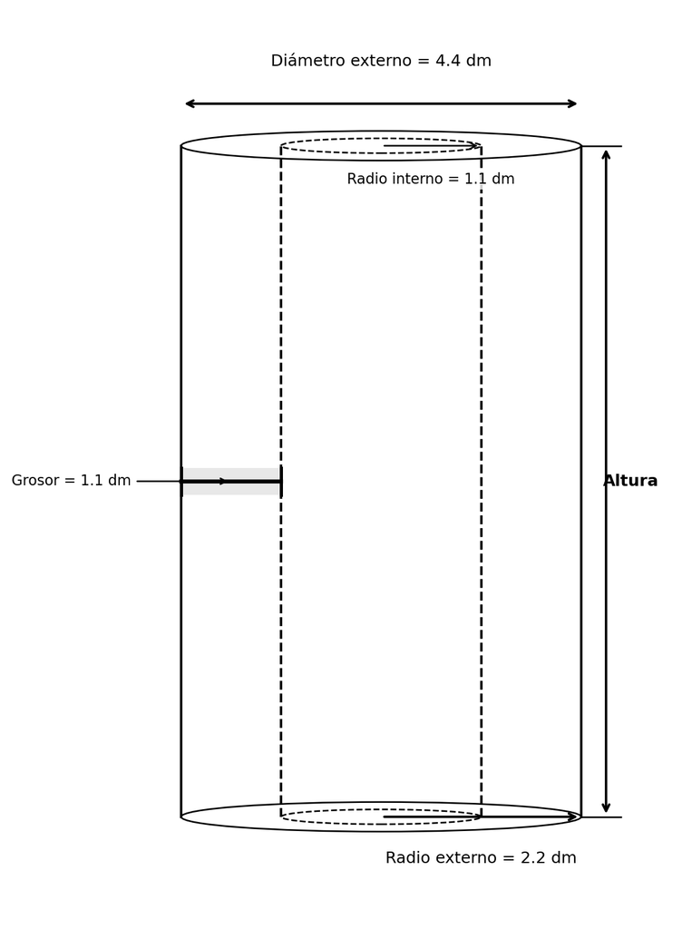

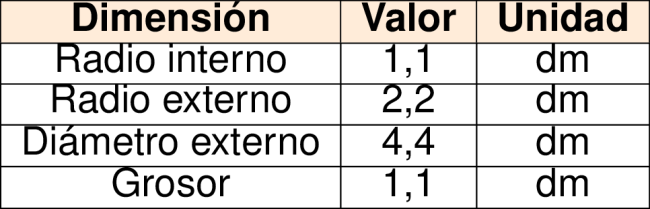

   ¿Cuál medida le falta a Lucía para hallar la cantidad deseada?
   1. Diámetro externo.
   2. Radio externo.
   3. Perímetro del cilindro.
   4. Altura del cilindro.

#### Solution

   La respuesta correcta es: **Altura del cilindro**.

   Para calcular el volumen de mezcla necesario para llenar el cañería cilíndrica vacío, necesitamos calcular el volumen de un cilindro, cuya fórmula es:

   $V = \pi \cdot r^2 \cdot h$

   Donde: - $r$ es el radio (en este caso, el radio interno = 1,1 dm) - $h$ es la altura del cilindro

   En el problema se nos proporciona: - Diámetro externo = 4,4 dm - Radio interno = 1,1 dm

   Sin embargo, no se nos proporciona la altura del cilindro, que es esencial para calcular el volumen. Por lo tanto, a Lucía le falta conocer la altura del cilindro para poder calcular la cantidad de mezcla necesaria.

   Si tuviéramos la altura, el volumen se calcularía así: $V = \pi \cdot (1,1)^2 \cdot h = 3,8 \cdot h$ dm³
   1. Falso
   2. Falso
   3. Falso
   4. Verdadero